# Naive Bayes with Mixed Feature Types — Wisconsin Breast Cancer (WDBC)

Biostatistics 735/794 — Machine Learning in Public Health (R)

Your Name

September 25, 2025

# Data: Wisconsin Diagnostic Breast Cancer (WDBC)

Each row is a patient. Outcome `Diagnosis` is **B**enign or **M**alignant. Predictors are 30 numeric features derived from FNA images.

```r
url_data  <- "https://archive.ics.uci.edu/ml/machine-learning-databases/breast-cancer-wisconsin/wdbc.data"
raw <- read.csv(url_data, header = FALSE)

names(raw) <- c("ID","Diagnosis",
                "radius_mean","texture_mean","perimeter_mean","area_mean","smoothness_mean",
                "compactness_mean","concavity_mean","concave_points_mean","symmetry_mean","fractal_dimension_mean",
                "radius_se","texture_se","perimeter_se","area_se","smoothness_se",
                "compactness_se","concavity_se","concave_points_se","symmetry_se","fractal_dimension_se",
                "radius_worst","texture_worst","perimeter_worst","area_worst","smoothness_worst",
                "compactness_worst","concavity_worst","concave_points_worst","symmetry_worst","fractal_dimension_worst")

bc <- raw %>%
  as_tibble() %>%
  mutate(Diagnosis = factor(Diagnosis, levels = c("B","M"))) %>%  # B = negative, M = positive
  select(-ID)

glimpse(bc)
```

```
## Rows: 569
## Columns: 31
## $ Diagnosis               <fct> M, M, M, M, M, M, M, M, M, M, M, M, M, M, M, M…
## $ radius_mean             <dbl> 17.990, 20.570, 19.690, 11.420, 20.290, 12.450…
## $ texture_mean            <dbl> 10.38, 17.77, 21.25, 20.38, 14.34, 15.70, 19.9…
## $ perimeter_mean          <dbl> 122.80, 132.90, 130.00, 77.58, 135.10, 82.57, …
## $ area_mean               <dbl> 1001.0, 1326.0, 1203.0, 386.1, 1297.0, 477.1, …
## $ smoothness_mean         <dbl> 0.11840, 0.08474, 0.10960, 0.14250, 0.10030, 0…
## $ compactness_mean        <dbl> 0.27760, 0.07864, 0.15990, 0.28390, 0.13280, 0…
## $ concavity_mean          <dbl> 0.30010, 0.08690, 0.19740, 0.24140, 0.19800, 0…
## $ concave_points_mean     <dbl> 0.14710, 0.07017, 0.12790, 0.10520, 0.10430, 0…
## $ symmetry_mean           <dbl> 0.2419, 0.1812, 0.2069, 0.2597, 0.1809, 0.2087…
## $ fractal_dimension_mean  <dbl> 0.07871, 0.05667, 0.05999, 0.09744, 0.05883, 0…
## $ radius_se               <dbl> 1.0950, 0.5435, 0.7456, 0.4956, 0.7572, 0.3345…
## $ texture_se              <dbl> 0.9053, 0.7339, 0.7869, 1.1560, 0.7813, 0.8902…
```

[output cut: 18 more lines]

```r
summary(bc$Diagnosis)
```

```
##   B   M
## 357 212
```

Train/test split (stratified):

```r
set.seed(42)
split <- initial_split(bc, prop = 0.8, strata = Diagnosis)
train <- training(split)
test  <- testing(split)

nrow(train); nrow(test)
```

```
## [1] 454
```

```
## [1] 115
```

A helper to compute the metrics we’ve discussed (AUC is threshold-free; others use a threshold, default 0.5):

```r
eval_metrics <- function(truth, prob_pos, thr = 0.5) {
  truth <- factor(truth, levels = c("B","M"))     # "M" is event
  cls   <- factor(ifelse(prob_pos >= thr, "M","B"), levels = c("B","M"))
  tibble(
    AUC  = roc_auc_vec(truth, prob_pos, event_level = "second"),
    Sens = sens_vec(truth, cls,        event_level = "second"),
    Spec = spec_vec(truth, cls,        event_level = "second"),
    PPV  = ppv_vec (truth, cls,        event_level = "second"),
    NPV  = npv_vec (truth, cls,        event_level = "second"),
    Acc  = accuracy_vec(truth, cls)
  )
}
```

# Part A — **Gaussian Naive Bayes** (treat all predictors as continuous)

`e1071::naiveBayes` models numeric predictors with a Gaussian density per class and factors with multinomial/Bernoulli. Here we keep **all 30 features numeric** → Gaussian NB.

```r
nb_gauss <- naiveBayes(Diagnosis ~ ., data = train, laplace = 0)  # no smoothing needed for continuous
# Posterior probability for Malignant ("M")
p_tr_g <- predict(nb_gauss, newdata = train, type = "raw")[,"M"]
p_te_g <- predict(nb_gauss, newdata = test,  type = "raw")[,"M"]

metrics_gauss <- bind_rows(
  eval_metrics(train$Diagnosis, p_tr_g) %>% mutate(Set = "Train"),
  eval_metrics(test$Diagnosis,  p_te_g) %>% mutate(Set = "Test")
) %>% relocate(Set)

kbl2(metrics_gauss, caption = "Gaussian Naive Bayes: Performance (threshold = 0.5)")
```

Gaussian Naive Bayes: Performance (threshold = 0.5)

| Set | AUC | Sens | Spec | PPV | NPV | Acc |
| --- | --- | --- | --- | --- | --- | --- |
| Train | 0.9878543 | 0.8994083 | 0.9578947 | 0.9268293 | 0.9413793 | 0.9361233 |
| Test | 0.9844961 | 0.9069767 | 0.9027778 | 0.8478261 | 0.9420290 | 0.9043478 |

ROC curve (train vs test):

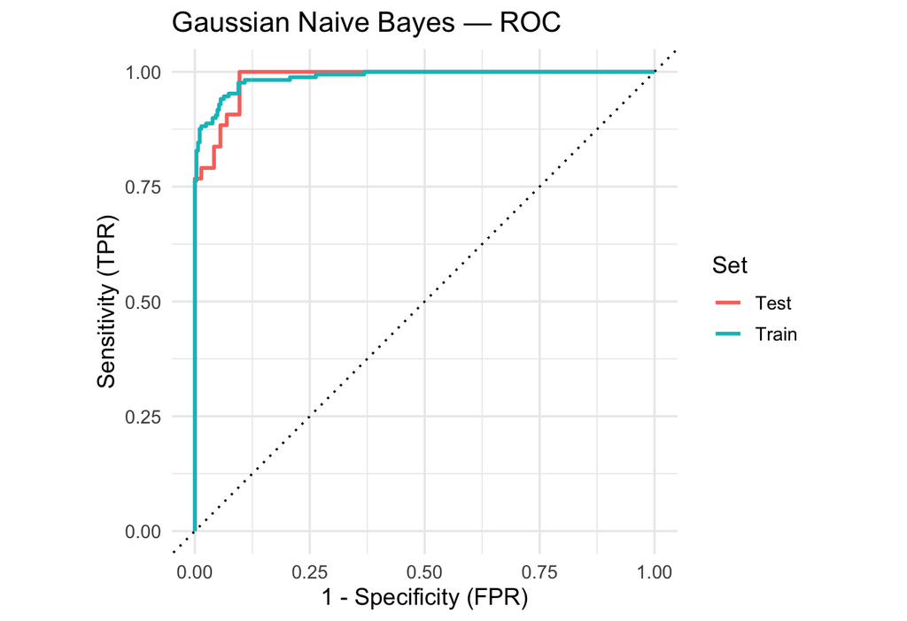

```r
train$estimate = p_tr_g
test$estimate = p_te_g
roc_train_g <- yardstick::roc_curve(data = train, Diagnosis, estimate, event_level = "second") %>% mutate(Set = "Train")
roc_test_g  <- yardstick::roc_curve(data = test, Diagnosis,  estimate, event_level = "second") %>% mutate(Set = "Test")

bind_rows(roc_train_g, roc_test_g) %>%
  ggplot(aes(x = 1 - specificity, y = sensitivity, color = Set)) +
  geom_path(linewidth = 1) + geom_abline(slope = 1, intercept = 0, linetype = 3) +
  coord_equal() + theme_minimal(base_size = 13) +
  labs(title = "Gaussian Naive Bayes — ROC", x = "1 - Specificity (FPR)", y = "Sensitivity (TPR)")
```

# Part B — **Mixed-Type Naive Bayes** (some binary, some multinomial, some continuous)

Here we transform a few predictors to **binary** (median split) and a few to **multinomial** (tertiles), and leave the rest **continuous**. `naiveBayes` will combine the appropriate likelihoods under the Naive assumption.

**Choices for this demo**

- Binary: `radius_mean`, `texture_mean`, `perimeter_mean` (High vs Low, median split)
- Multinomial (3-level): `area_mean`, `smoothness_mean` (Low/Med/High via tertiles)
- Continuous: all remaining features stay numeric

```r
make_mixed <- function(df) {
  out <- df

  # Binary via median split
  for (v in c("radius_mean","texture_mean","perimeter_mean")) {
    med <- median(out[[v]], na.rm = TRUE)
    out[[paste0(v,"_bin")]] <- factor(ifelse(out[[v]] > med, "High","Low"))
    out[[v]] <- NULL
  }

  # Multinomial via tertiles
  for (v in c("area_mean","smoothness_mean")) {
    qs <- quantile(out[[v]], probs = c(1/3, 2/3), na.rm = TRUE)
    cutv <- cut(out[[v]],
                breaks = c(-Inf, qs[1], qs[2], Inf),
                labels = c("Low","Med","High"),
                right = TRUE)
    out[[paste0(v,"_ter")]] <- factor(cutv)
    out[[v]] <- NULL
  }

  out
}

train_mx <- make_mixed(train)
test_mx  <- make_mixed(test)

glimpse(train_mx)
```

```
## Rows: 454
## Columns: 32
## $ Diagnosis               <fct> B, B, B, B, B, B, B, B, B, B, B, B, B, B, B, B…
## $ compactness_mean        <dbl> 0.08129, 0.12700, 0.06492, 0.03766, 0.05943, 0…
## $ concavity_mean          <dbl> 0.066640, 0.045680, 0.029560, 0.025620, 0.0158…
## $ concave_points_mean     <dbl> 0.047810, 0.031100, 0.020760, 0.029230, 0.0059…
## $ symmetry_mean           <dbl> 0.1885, 0.1967, 0.1815, 0.1467, 0.1769, 0.1675…
## $ fractal_dimension_mean  <dbl> 0.05766, 0.06811, 0.06905, 0.05863, 0.06503, 0…
## $ radius_se               <dbl> 0.2699, 0.1852, 0.2773, 0.1839, 0.1563, 0.2636…
## $ texture_se              <dbl> 0.7886, 0.7477, 0.9768, 2.3420, 0.9567, 0.7294…
## $ perimeter_se            <dbl> 2.058, 1.383, 1.909, 1.170, 1.094, 1.848, 1.73…
## $ area_se                 <dbl> 23.560, 14.670, 15.700, 14.160, 8.205, 19.870,…
## $ smoothness_se           <dbl> 0.008462, 0.004097, 0.009606, 0.004352, 0.0089…
## $ compactness_se          <dbl> 0.014600, 0.018980, 0.014320, 0.004899, 0.0164…
## $ concavity_se            <dbl> 0.023870, 0.016980, 0.019850, 0.013430, 0.0158…
```

[output cut: 19 more lines]

Fit Naive Bayes with **Laplace smoothing** (recommended when categorical levels can be rare):

```r
nb_mixed <- naiveBayes(Diagnosis ~ ., data = train_mx, laplace = 1)

p_tr_mx <- predict(nb_mixed, newdata = train_mx, type = "raw")[,"M"]
p_te_mx <- predict(nb_mixed, newdata = test_mx,  type = "raw")[,"M"]

metrics_mixed <- bind_rows(
  eval_metrics(train_mx$Diagnosis, p_tr_mx) %>% mutate(Set = "Train"),
  eval_metrics(test_mx$Diagnosis,  p_te_mx) %>% mutate(Set = "Test")
) %>% relocate(Set)

kbl2(metrics_mixed, caption = "Mixed-Type Naive Bayes (binary + multinomial + continuous): Performance (threshold = 0.5)")
```

Mixed-Type Naive Bayes (binary + multinomial + continuous): Performance (threshold = 0.5)

| Set | AUC | Sens | Spec | PPV | NPV | Acc |
| --- | --- | --- | --- | --- | --- | --- |
| Train | 0.9868577 | 0.8994083 | 0.9578947 | 0.9268293 | 0.9413793 | 0.9361233 |
| Test | 0.9867571 | 0.9069767 | 0.9027778 | 0.8478261 | 0.9420290 | 0.9043478 |

ROC curve (train vs test) for the mixed model:

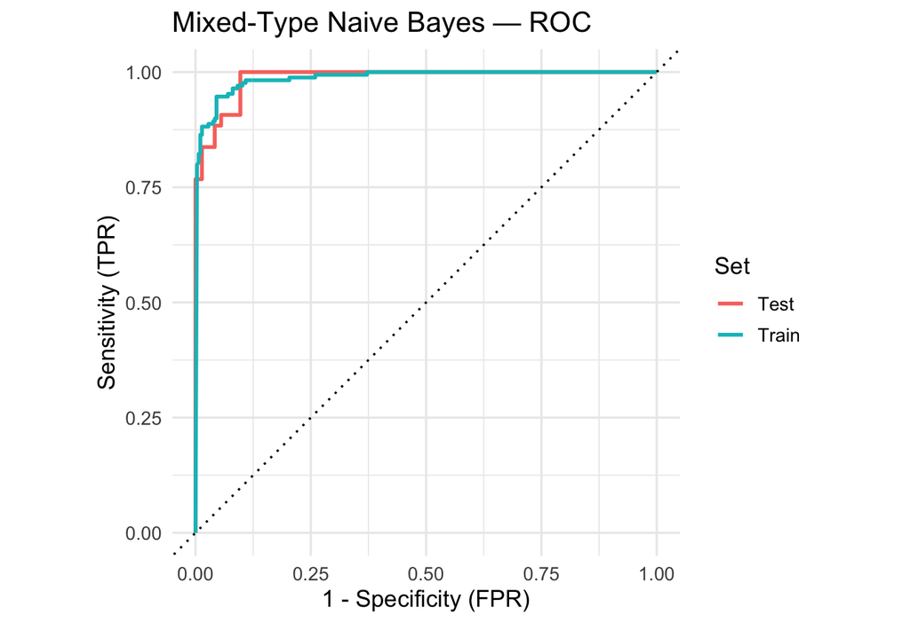

```r
train$estimate_mx = p_tr_mx
test$estimate_mx = p_te_mx
roc_train_m <- yardstick::roc_curve(data = train, Diagnosis, estimate_mx, event_level = "second") %>% mutate(Set = "Train")
roc_test_m  <- yardstick::roc_curve(data = test, Diagnosis,  estimate_mx, event_level = "second") %>% mutate(Set = "Test")


bind_rows(roc_train_m, roc_test_m) %>%
  ggplot(aes(x = 1 - specificity, y = sensitivity, color = Set)) +
  geom_path(size = 1) + geom_abline(slope = 1, intercept = 0, linetype = 3) +
  coord_equal() + theme_minimal(base_size = 13) +
  labs(title = "Mixed-Type Naive Bayes — ROC", x = "1 - Specificity (FPR)", y = "Sensitivity (TPR)")
```

## Optional — Threshold tuning by Youden’s J (for either model)

Pick a threshold on the **training** set that maximizes Youden’s Index $J = \text{Sens} + \text{Spec} - 1$, then evaluate on test.

**Note:** This version is improved over before.

```r
tune_threshold_j <- function(truth, prob, grid = NULL) {
  if(is.null(grid)){grid <- c(0,sort(unique(prob)),1)}

  truth <- factor(truth, levels = c("B","M"))
  best_t <- NULL; best_j <- -Inf

  for (t in grid) {
    cls <- factor(ifelse(prob >= t, "M","B"), levels = c("B","M"))
    se <- sens_vec(truth, cls, event_level = "second")
    sp <- spec_vec(truth, cls, event_level = "second")
    j  <- as.numeric(se + sp - 1)
    if (!is.na(j) && j >= best_j) {
      best_t <- c(best_t,t)
      if(j > best_j){best_t <- t}

      best_j <- j
    }
  }
  sum(range(best_t))/2
}

thr_g <- tune_threshold_j(train$Diagnosis, p_tr_g)
thr_m <- tune_threshold_j(train_mx$Diagnosis, p_tr_mx)

perf_tuned <- bind_rows(
  eval_metrics(train$Diagnosis,    p_tr_g, thr_g) %>% mutate(Model = "Gaussian NB", Set = "Train", Thr = round(thr_g,3)),
  eval_metrics(test$Diagnosis,     p_te_g, thr_g) %>% mutate(Model = "Gaussian NB", Set = "Test",  Thr = round(thr_g,3)),
  eval_metrics(train_mx$Diagnosis, p_tr_mx, thr_m) %>% mutate(Model = "Mixed NB",    Set = "Train", Thr = round(thr_m,3)),
  eval_metrics(test_mx$Diagnosis,  p_te_mx, thr_m) %>% mutate(Model = "Mixed NB",    Set = "Test",  Thr = round(thr_m,3))
) %>% relocate(Model, Set, Thr)

kbl2(perf_tuned, caption = "Performance with Youden-tuned thresholds (threshold chosen on training set)")
```

Performance with Youden-tuned thresholds (threshold chosen on training set)

| Model | Set | Thr | AUC | Sens | Spec | PPV | NPV | Acc |
| --- | --- | --- | --- | --- | --- | --- | --- | --- |
| Gaussian NB | Train | 0.007 | 0.9878543 | 0.9408284 | 0.9438596 | 0.9085714 | 0.9641577 | 0.9427313 |
| Gaussian NB | Test | 0.007 | 0.9844961 | 0.9302326 | 0.9027778 | 0.8510638 | 0.9558824 | 0.9130435 |
| Mixed NB | Train | 0.002 | 0.9868577 | 0.9467456 | 0.9543860 | 0.9248555 | 0.9679715 | 0.9515419 |
| Mixed NB | Test | 0.002 | 0.9867571 | 0.9302326 | 0.9027778 | 0.8510638 | 0.9558824 | 0.9130435 |

## Summary

- **Naive Bayes is a framework**: multiply class-conditional likelihoods per feature under conditional independence.
- With `e1071::naiveBayes`, **numeric** variables are modeled as **Gaussian**; **factors** are modeled as **multinomial/Bernoulli** with optional **Laplace smoothing**.
- You can **mix feature types** in the same model (as we did with binary + multinomial + continuous).
- Report both **threshold-free (AUC)** and **thresholded (Se/Sp/PPV/NPV/Acc)** performance; optionally **tune the threshold** (e.g., Youden’s J) on training and report test-set results.

# Part C — **Kernel-Density Naive Bayes** (non-parametric for continuous features)

Not all of the variables have a normal distribution. For example,

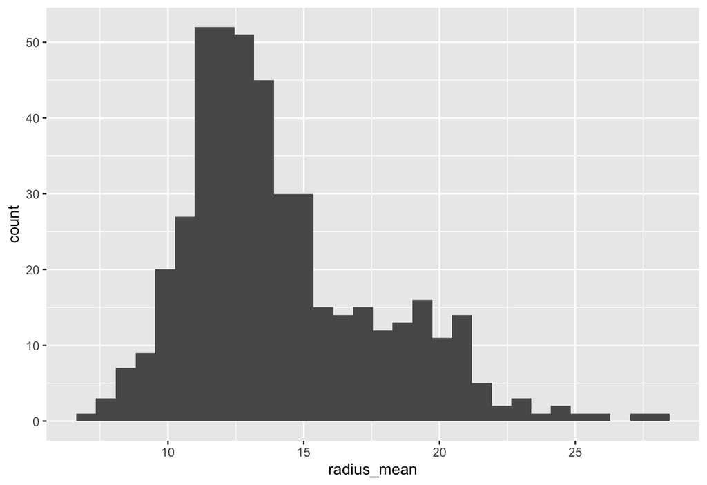

```r
ggplot(data = train) + geom_histogram(aes(radius_mean))
```

We now replace the Gaussian assumption for continuous variables with **kernel density estimates** (KDE) per class and per feature. This lets us capture skewness, heavy tails, and multi-modality that a Normal model can’t.

## Fit/predict helpers for KDE-NB

```r
# ----- Utilities -----

# Stable log-sum-exp for posterior normalization
logsumexp <- function(z) {
  m <- max(z)
  m + log(sum(exp(z - m)))
}

# Build Laplace-smoothed class-conditional probability tables for factor features
fit_factor_tables <- function(df, y, alpha = 1) {
  lev_y <- levels(y)
  facs  <- names(df)[vapply(df, is.factor, logical(1))]
  out <- vector("list", length(facs)); names(out) <- facs
  for (f in facs) {
    tab <- table(y, df[[f]])
    # Laplace smoothing by row (class)
    tab_sm <- sweep(tab + alpha, 1, rowSums(tab) + alpha * ncol(tab), "/")
    out[[f]] <- as.matrix(tab_sm)[lev_y, , drop = FALSE]
  }
  out
}

# For continuous features: per-class KDE objects + interpolators
fit_kde_tables <- function(df, y, bw = "nrd0", adjust = 1, kernel = "gaussian", gridsize = 512) {
  nums <- names(df)[vapply(df, is.numeric, logical(1))]
  lev_y <- levels(y)
  out <- vector("list", length(nums)); names(out) <- nums
  for (v in nums) {
    dens_list <- vector("list", length(lev_y)); names(dens_list) <- lev_y
    for (k in lev_y) {
      xk <- df[[v]][y == k]
      # Handle degenerate cases: if all equal, jitter slightly
      if (sd(xk, na.rm = TRUE) == 0) {
        xk <- xk + rnorm(length(xk), sd = 1e-8)
      }
      dk <- density(xk, bw = bw, adjust = adjust, kernel = kernel, n = gridsize)
      # Interpolator; rule=2 for constant extrapolation at tails
      fk <- approxfun(dk$x, dk$y, rule = 2)
      dens_list[[k]] <- list(x = dk$x, y = dk$y, f = fk)
    }
    out[[v]] <- dens_list
  }
  out
}

# ----- Model fit -----
naive_bayes_kde_fit <- function(data, yvar = "Diagnosis", alpha = 1,
                                bw = "nrd0", adjust = 1, kernel = "gaussian") {
  y <- factor(data[[yvar]])
  X <- data[, setdiff(names(data), yvar), drop = FALSE]
  priors <- prop.table(table(y))
  fac_tables <- fit_factor_tables(X, y, alpha = alpha)
  kde_tables <- fit_kde_tables(X, y, bw = bw, adjust = adjust, kernel = kernel)
  list(yvar = yvar,
       priors = priors,
       fac_tables = fac_tables,
       kde_tables = kde_tables,
       levels = levels(y),
       num_vars = names(kde_tables),
       fac_vars = names(fac_tables),
       alpha = alpha)
}

# ----- Prediction (posterior for positive class "M") -----
naive_bayes_kde_predict_proba <- function(model, newdata, positive = "M", eps = 1e-12) {
  lev_y <- model$levels
  X <- newdata[, setdiff(names(newdata), model$yvar), drop = FALSE]
  n <- nrow(X)
  log_post <- matrix(NA_real_, nrow = n, ncol = length(lev_y))
  colnames(log_post) <- lev_y
  # Precompute logs of priors
  log_prior <- log(as.numeric(model$priors)[match(lev_y, names(model$priors))])
  for (i in seq_len(n)) {
    # For each class, accumulate log-likelihoods
    for (k in seq_along(lev_y)) {
      kk <- lev_y[k]
      lp <- log_prior[k]
      # numeric vars via KDE
      for (v in model$num_vars) {
        if (!is.null(model$kde_tables[[v]][[kk]])) {
          dens_val <- model$kde_tables[[v]][[kk]]$f(X[[v]][i])
          lp <- lp + log(pmax(dens_val, eps))
        }
      }
      # factor vars via Laplace-smoothed tables
      for (f in model$fac_vars) {
        tab <- model$fac_tables[[f]]
        lvl <- as.character(X[[f]][i])
        if (!is.na(lvl) && lvl %in% colnames(tab)) {
          lp <- lp + log(pmax(tab[kk, lvl], eps))
        } else {
          # unseen level → uniform tiny mass
          lp <- lp + log(eps)
        }
      }
      log_post[i, k] <- lp
    }
  }
  # softmax to probabilities
  probs <- t(apply(log_post, 1, function(z) {
    denom <- logsumexp(z)
    exp(z - denom)
  }))
  as.numeric(probs[, match(positive, lev_y)])
}
```

## Build mixed feature set (reuse Part B) and fit KDE-NB

We’ll use the **same mixed feature construction** as before (binary + multinomial + remaining continuous), but now the continuous features are modeled with KDE instead of Gaussians.

```r
# Reuse make_mixed(train) from Part B
train_kde <- make_mixed(train)
test_kde  <- make_mixed(test)

# Fit KDE-NB (Laplace=1 for categorical features; KDE for numeric)
kde_nb <- naive_bayes_kde_fit(train_kde, yvar = "Diagnosis", alpha = 1,
                              bw = "nrd0", adjust = 1, kernel = "gaussian")

# Posterior P(M | X)
p_tr_kde <- naive_bayes_kde_predict_proba(kde_nb, train_kde)
p_te_kde <- naive_bayes_kde_predict_proba(kde_nb, test_kde)

metrics_kde <- bind_rows(
  eval_metrics(train_kde$Diagnosis, p_tr_kde) %>% mutate(Set = "Train"),
  eval_metrics(test_kde$Diagnosis,  p_te_kde) %>% mutate(Set = "Test")
) %>% relocate(Set)

kbl2(metrics_kde, caption = "Kernel-Density Naive Bayes (mixed features): Performance (threshold = 0.5)")
```

Kernel-Density Naive Bayes (mixed features): Performance (threshold = 0.5)

| Set | AUC | Sens | Spec | PPV | NPV | Acc |
| --- | --- | --- | --- | --- | --- | --- |
| Train | 0.9911969 | 0.9230769 | 0.9929825 | 0.9873418 | 0.9560811 | 0.9669604 |
| Test | 0.9832041 | 0.8372093 | 0.9722222 | 0.9473684 | 0.9090909 | 0.9217391 |

ROC curves for KDE-NB:

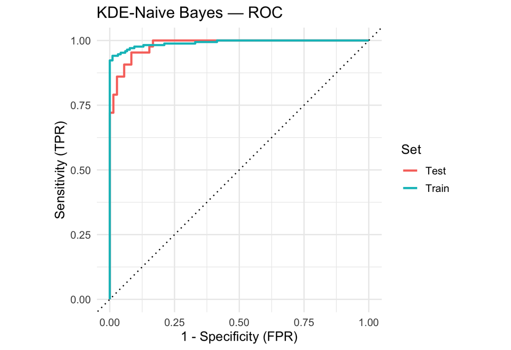

```r
train$estimate_kde = p_tr_kde
test$estimate_kde = p_te_kde
roc_train_kde <- yardstick::roc_curve(data = train, Diagnosis, estimate_kde, event_level = "second") %>% mutate(Set = "Train")
roc_test_kde  <- yardstick::roc_curve(data = test, Diagnosis,  estimate_kde, event_level = "second") %>% mutate(Set = "Test")


bind_rows(roc_train_kde, roc_test_kde) %>%
  ggplot(aes(x = 1 - specificity, y = sensitivity, color = Set)) +
  geom_path(size = 1) + geom_abline(slope = 1, intercept = 0, linetype = 3) +
  coord_equal() + theme_minimal(base_size = 13) +
  labs(title = "KDE-Naive Bayes — ROC", x = "1 - Specificity (FPR)", y = "Sensitivity (TPR)")
```

## Compare Gaussian NB vs Mixed NB vs KDE-NB (test set)

```r
compare_tbl <- tibble(
  Model = c("Gaussian NB", "Mixed NB", "KDE-NB"),
  AUC   = c(
    roc_auc_vec(test$Diagnosis,     p_te_g,   event_level = "second"),
    roc_auc_vec(test_mx$Diagnosis,  p_te_mx,  event_level = "second"),
    roc_auc_vec(test_kde$Diagnosis, p_te_kde, event_level = "second")
  ),
  Sens  = c(
    sens_vec(test$Diagnosis,    factor(ifelse(p_te_g   >= 0.5, "M","B"), levels=c("B","M")), event_level = "second"),
    sens_vec(test_mx$Diagnosis, factor(ifelse(p_te_mx  >= 0.5, "M","B"), levels=c("B","M")), event_level = "second"),
    sens_vec(test_kde$Diagnosis,factor(ifelse(p_te_kde >= 0.5, "M","B"), levels=c("B","M")), event_level = "second")
  ),
  Spec  = c(
    spec_vec(test$Diagnosis,    factor(ifelse(p_te_g   >= 0.5, "M","B"), levels=c("B","M")), event_level = "second"),
    spec_vec(test_mx$Diagnosis, factor(ifelse(p_te_mx  >= 0.5, "M","B"), levels=c("B","M")), event_level = "second"),
    spec_vec(test_kde$Diagnosis,factor(ifelse(p_te_kde >= 0.5, "M","B"), levels=c("B","M")), event_level = "second")
  ),
  PPV   = c(
    ppv_vec(test$Diagnosis,    factor(ifelse(p_te_g   >= 0.5, "M","B"), levels=c("B","M")), event_level = "second"),
    ppv_vec(test_mx$Diagnosis, factor(ifelse(p_te_mx  >= 0.5, "M","B"), levels=c("B","M")), event_level = "second"),
    ppv_vec(test_kde$Diagnosis,factor(ifelse(p_te_kde >= 0.5, "M","B"), levels=c("B","M")), event_level = "second")
  ),
  NPV   = c(
    npv_vec(test$Diagnosis,    factor(ifelse(p_te_g   >= 0.5, "M","B"), levels=c("B","M")), event_level = "second"),
    npv_vec(test_mx$Diagnosis, factor(ifelse(p_te_mx  >= 0.5, "M","B"), levels=c("B","M")), event_level = "second"),
    npv_vec(test_kde$Diagnosis,factor(ifelse(p_te_kde >= 0.5, "M","B"), levels=c("B","M")), event_level = "second")
  ),
  Acc   = c(
    accuracy_vec(test$Diagnosis,    factor(ifelse(p_te_g   >= 0.5, "M","B"), levels=c("B","M"))),
    accuracy_vec(test_mx$Diagnosis, factor(ifelse(p_te_mx  >= 0.5, "M","B"), levels=c("B","M"))),
    accuracy_vec(test_kde$Diagnosis,factor(ifelse(p_te_kde >= 0.5, "M","B"), levels=c("B","M")))
  )
)

kbl2(compare_tbl, caption = "Test-set comparison: Gaussian NB vs Mixed NB vs KDE-NB (threshold = 0.5)")
```

Test-set comparison: Gaussian NB vs Mixed NB vs KDE-NB (threshold = 0.5)

| Model | AUC | Sens | Spec | PPV | NPV | Acc |
| --- | --- | --- | --- | --- | --- | --- |
| Gaussian NB | 0.9844961 | 0.9069767 | 0.9027778 | 0.8478261 | 0.9420290 | 0.9043478 |
| Mixed NB | 0.9867571 | 0.9069767 | 0.9027778 | 0.8478261 | 0.9420290 | 0.9043478 |
| KDE-NB | 0.9832041 | 0.8372093 | 0.9722222 | 0.9473684 | 0.9090909 | 0.9217391 |

## (Optional) Tune thresholds by Youden’s J for KDE-NB

```r
thr_kde <- tune_threshold_j(train_kde$Diagnosis, p_tr_kde)

perf_kde_tuned <- bind_rows(
  eval_metrics(train_kde$Diagnosis, p_tr_kde, thr_kde) %>% mutate(Model = "KDE-NB", Set = "Train", Thr = round(thr_kde,3)),
  eval_metrics(test_kde$Diagnosis,  p_te_kde, thr_kde) %>% mutate(Model = "KDE-NB", Set = "Test",  Thr = round(thr_kde,3))
) %>% relocate(Model, Set, Thr)

kbl2(perf_kde_tuned, caption = "KDE-Naive Bayes with Youden-tuned threshold (chosen on training set)")
```

KDE-Naive Bayes with Youden-tuned threshold (chosen on training set)

| Model | Set | Thr | AUC | Sens | Spec | PPV | NPV | Acc |
| --- | --- | --- | --- | --- | --- | --- | --- | --- |
| KDE-NB | Train | 0 | 0.9911969 | 0.9408284 | 0.9894737 | 0.9814815 | 0.9657534 | 0.9713656 |
| KDE-NB | Test | 0 | 0.9832041 | 0.9069767 | 0.9444444 | 0.9069767 | 0.9444444 | 0.9304348 |

**Notes**

- KDE-NB **drops the Normality assumption** for continuous features; it can adapt to skewed or multi-modal FNA features.
- We **mix** modeling choices: categorical features use **smoothed class-conditional probabilities**, continuous features use **KDE** — all multiplied under the Naive independence assumption.
- Trade-offs: KDE adds flexibility but may overfit with tiny class-specific samples; bandwidth (`bw`, `adjust`) acts like a **smoothness** tuning parameter.

# Part D — **Gaussian Naive Bayes with cost**

Here, we’ll repeat the Gaussian NB example except we’ll incorporate a cost function.

```r
nb_gauss <- naiveBayes(Diagnosis ~ ., data = train, laplace = 0)  # no smoothing needed for continuous
# Posterior probability for Malignant ("M")
p_tr_g <- predict(nb_gauss, newdata = train, type = "raw")[,"M"]
p_te_g <- predict(nb_gauss, newdata = test,  type = "raw")[,"M"]

#### For screening, let's say a false negative (FN), saying a diseased person is healthy,
#### is 10 times more costly than a false positive (FP), saying a healthy person is diseased.
#### When a FN is K times more costly, the natural threshold is 1/(K+1)
metrics_gauss_screen <- bind_rows(
  eval_metrics(train$Diagnosis, p_tr_g, thr = 1/11) %>% mutate(Set = "Train"),
  eval_metrics(test$Diagnosis,  p_te_g, thr = 1/11) %>% mutate(Set = "Test")
) %>% mutate(Type = "Screen", Threshold = 1/11) %>% relocate(Set,Type, Threshold)

#### For confirmation, let's say an FP is 10 times more costly than an FN.
#### When a FP is K times more costly, the natural threshold is K/(K+1)
metrics_gauss_confrm <- bind_rows(
  eval_metrics(train$Diagnosis, p_tr_g, thr = 10/11) %>% mutate(Set = "Train"),
  eval_metrics(test$Diagnosis,  p_te_g, thr = 10/11) %>% mutate(Set = "Test")
) %>% mutate(Type = "Confirm", Threshold = 10/11) %>% relocate(Set,Type, Threshold)

#### Overall
metrics_gauss <- metrics_gauss %>%
  mutate(Type = "Overall", Threshold = 0.5) %>% relocate(Set,Type, Threshold)

#### Using a Youden-tuned threshold
thr_gauss <- tune_threshold_j(train$Diagnosis, p_tr_g)

metrics_gauss_tuned <- bind_rows(
  eval_metrics(train$Diagnosis, p_tr_g, thr_gauss) %>% mutate(Set = "Train"),
  eval_metrics(test$Diagnosis,  p_te_g, thr_gauss) %>% mutate(Set = "Test")
) %>%
  mutate(Type = "Youden", Threshold = thr_gauss) %>% relocate(Set, Type, Threshold)

kbl2(metrics_gauss %>%
       bind_rows(metrics_gauss_tuned) %>%
       bind_rows(metrics_gauss_screen) %>%
       bind_rows(metrics_gauss_confrm) %>%
       filter(Set == "Test"), caption = "Gaussian Naive Bayes comparison for test set", digits = 3)
```

Gaussian Naive Bayes comparison for test set

[output not shown]

```r
par(c(2,1))
```

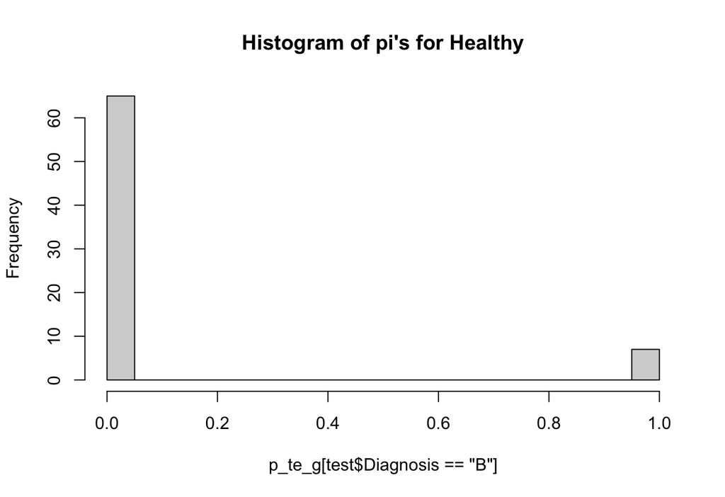

```r
hist(p_te_g[test$Diagnosis=="B"], breaks = 30, main = "Histogram of pi's for Healthy")
```

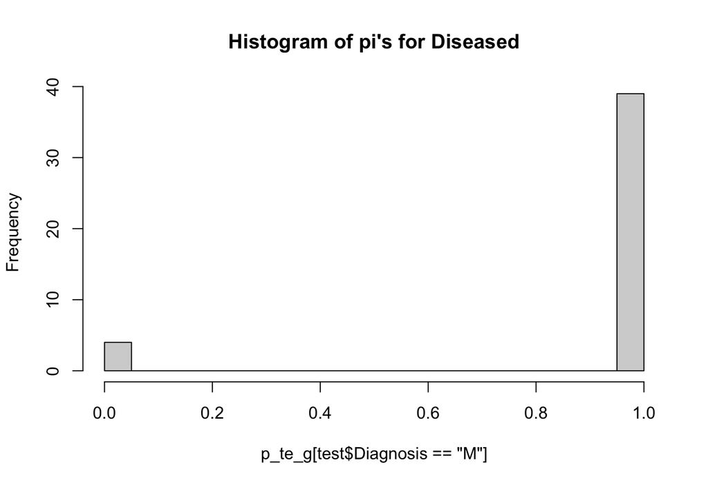

```r
hist(p_te_g[test$Diagnosis=="M"], breaks = 30, main = "Histogram of pi's for Diseased")
```

**Notes**